# HomeWork_6

Vincent Tamakloe

2025-02-19

## Generating Simulated Data Sets To Explore Hypotheses

### Introduction

For this assignment, I will simulate a dataset based on an experimental hypothesis related to insect pheromone communication in agricultural pest management. Specifically, I will explore how different pheromone concentrations affect swede midge (*Contarinia nasturtii*) mating behavior. I assume that mating frequency follows a normal distribution across treatment groups.

### Hypothesis

I hypothesize that increased pheromone concentration leads to a significant reduction in mating frequency. To test this, I will simulate four treatment groups, including a control:  
-*Control group*: Expected baseline mating frequency  
-*Low pheromone*: Expected high mating frequency  
-*Medium pheromone*: Intermediate mating frequency  
-*High pheromone*: Low mating frequency

Assumed parameters:  
- *Sample size per group* = 30  
- *Means:* *Control* = 20, *Low* = 15, *Medium* = 10, *High* = 5  
- *Standard deviation*: 3 for all treatment groups

### Data Simulation

```r
set.seed(123)  # Ensure reproducibility

# Define sample sizes, means, and standard deviations
sample_size <- 30
treatments <- c("Control", "Low", "Medium", "High")
means <- c(20, 15, 10, 5)
sd <- 3

# Generate random data from normal distributions
data <- data.frame(
  Treatment = rep(treatments, each = sample_size),
  MatingFrequency = c(
    rnorm(sample_size, mean = means[1], sd = sd),
    rnorm(sample_size, mean = means[2], sd = sd),
    rnorm(sample_size, mean = means[3], sd = sd),
    rnorm(sample_size, mean = means[4], sd = sd)
  )
)

head(data)
```

```
##   Treatment MatingFrequency
## 1   Control        18.31857
## 2   Control        19.30947
## 3   Control        24.67612
## 4   Control        20.21153
## 5   Control        20.38786
## 6   Control        25.14519
```

### Data Visualization

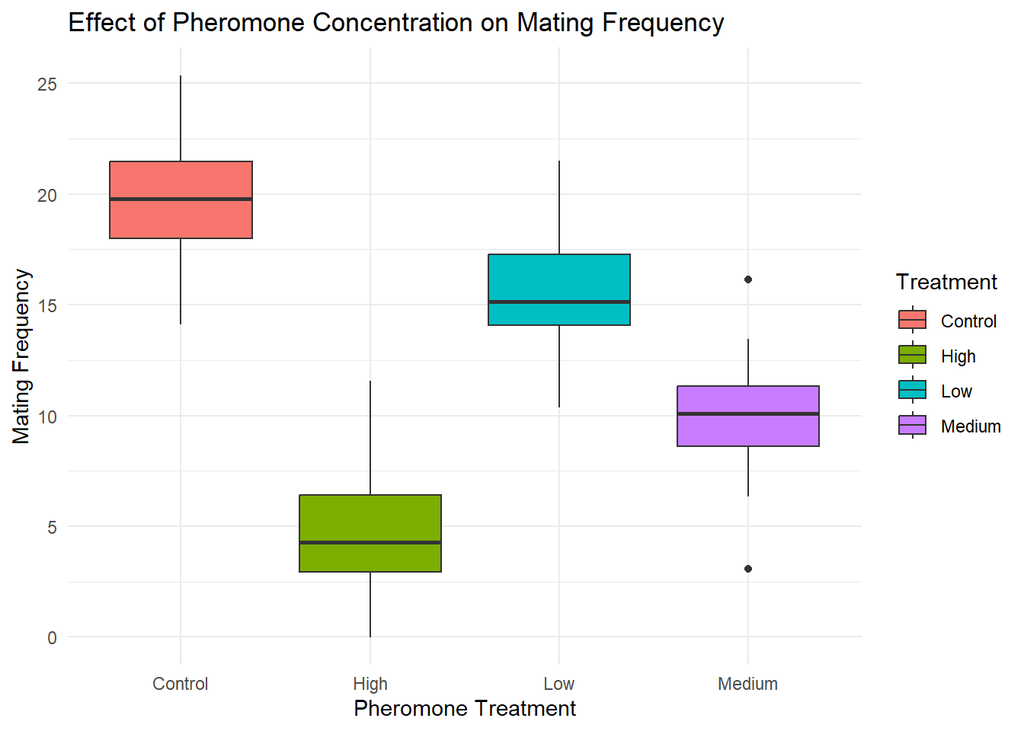

```r
library(ggplot2)

ggplot(data, aes(x = Treatment, y = MatingFrequency, fill = Treatment)) +
  geom_boxplot() +
  theme_minimal() +
  labs(title = "Effect of Pheromone Concentration on Mating Frequency",
       x = "Pheromone Treatment",
       y = "Mating Frequency")
```

### ANOVA Analysis

```r
# Perform ANOVA to test for significant differences
anova_model <- aov(MatingFrequency ~ Treatment, data = data)
summary(anova_model)
```

```
##              Df Sum Sq Mean Sq F value Pr(>F)
## Treatment     3   3894  1298.0   178.1 <2e-16 ***
## Residuals   116    845     7.3
## ---
## Signif. codes:  0 '***' 0.001 '**' 0.01 '*' 0.05 '.' 0.1 ' ' 1
```

### Sample Size Effects

```r
# Function to test different sample sizes
test_sample_sizes <- function(sample_sizes) {
  results <- data.frame(SampleSize = numeric(), p_value = numeric())

  for (n in sample_sizes) {
    new_data <- data.frame(
      Treatment = rep(treatments, each = n),
      MatingFrequency = c(
        rnorm(n, mean = means[1], sd = sd),  # Control group
        rnorm(n, mean = means[2], sd = sd),  # Low pheromone
        rnorm(n, mean = means[3], sd = sd),  # Medium pheromone
        rnorm(n, mean = means[4], sd = sd)   # High pheromone
      )
    )

    model <- aov(MatingFrequency ~ Treatment, data = new_data)
    p_val <- summary(model)[[1]][["Pr(>F)"]][1]

    results <- rbind(results, data.frame(SampleSize = n, p_value = p_val))
  }

  return(results)
}

# Test sample sizes from 10 to 100 in increments of 10
sample_sizes <- seq(10, 100, by = 10)
sample_size_results <- test_sample_sizes(sample_sizes)

print(sample_size_results)
```

```
##    SampleSize       p_value
## 1          10  1.230876e-11
## 2          20  6.626228e-27
## 3          30  1.102190e-38
## 4          40  6.430344e-52
## 5          50  2.470532e-68
## 6          60  4.835158e-75
## 7          70  5.829418e-91
## 8          80 9.364952e-107
## 9          90 5.731405e-109
## 10        100 1.273503e-141
```

### Conclusion

This study highlights the impact of pheromone concentration on swede midge mating behavior and the role of sample size in detecting statistically significant differences. The results demonstrate that higher pheromone concentrations reduce mating frequency, supporting the hypothesis.

Overall, this simulation provides valuable insights into experimental design and the importance of robust statistical analysis in ecological research.